# Data Wrangling and Graphing COVID-19 Reporting Data (Part 1)

## Exercise Challenges (Part 1)

### Challenge Exercise 1

The format of the daily reports has changed over time. What are the differences between 3/12/2020, the Friday before spring break 2020 and yesterday 6 months later on 9/12/2020? Load the files into R and use str() and View() (or in the top right corner click on Environment and then the data frame.). Note the in the more recent dates they have changed the column headers so that it is no longer necessary to rename Province_State and Country_Region.

```r
library(tidyverse)
# Read csv file into R
report_03_12_2020 <-   read_csv(url("https://raw.githubusercontent.com/CSSEGISandData/COVID-19/master/csse_covid_19_data/csse_covid_19_daily_reports/03-12-2020.csv")) %>%
  rename(Country_Region = "Country/Region", Province_State = "Province/State")
report_09_12_2020 <-   read_csv(url("https://raw.githubusercontent.com/CSSEGISandData/COVID-19/master/csse_covid_19_data/csse_covid_19_daily_reports/09-12-2020.csv"))
str(report_03_12_2020)
```

```
## tibble [218 × 8] (S3: spec_tbl_df/tbl_df/tbl/data.frame)
##  $ Province_State: chr [1:218] "Hubei" NA NA NA ...
##  $ Country_Region: chr [1:218] "China" "Italy" "Iran" "Korea, South" ...
##  $ Last Update   : POSIXct[1:218], format: "2020-03-12 09:53:06" "2020-03-11 21:33:02" ...
##  $ Confirmed     : num [1:218] 67781 12462 10075 7869 2281 ...
##  $ Deaths        : num [1:218] 3056 827 429 66 48 ...
##  $ Recovered     : num [1:218] 50318 1045 2959 333 12 ...
##  $ Latitude      : num [1:218] 31 43 32 36 46.2 ...
##  $ Longitude     : num [1:218] 112.27 12 53 128 2.21 ...
##  - attr(*, "spec")=
##   .. cols(
##   ..   `Province/State` = col_character(),
##   ..   `Country/Region` = col_character(),
##   ..   `Last Update` = col_datetime(format = ""),
##   ..   Confirmed = col_double(),
##   ..   Deaths = col_double(),
##   ..   Recovered = col_double(),
##   ..   Latitude = col_double(),
##   ..   Longitude = col_double()
##   .. )
```

```r
str(report_09_12_2020)
```

```
## tibble [3,954 × 14] (S3: spec_tbl_df/tbl_df/tbl/data.frame)
##  $ FIPS               : num [1:3954] NA NA NA NA NA NA NA NA NA NA ...
##  $ Admin2             : chr [1:3954] NA NA NA NA ...
##  $ Province_State     : chr [1:3954] NA NA NA NA ...
##  $ Country_Region     : chr [1:3954] "Afghanistan" "Albania" "Algeria" "Andorra" ...
##  $ Last_Update        : POSIXct[1:3954], format: "2020-09-13 04:30:52" "2020-09-13 04:30:52" ...
##  $ Lat                : num [1:3954] 33.9 41.2 28 42.5 -11.2 ...
##  $ Long_              : num [1:3954] 67.71 20.17 1.66 1.52 17.87 ...
##  $ Confirmed          : num [1:3954] 38641 11185 48007 1344 3335 ...
##  $ Deaths             : num [1:3954] 1420 330 1605 53 132 ...
##  $ Recovered          : num [1:3954] 31234 6494 33875 943 1289 ...
##  $ Active             : num [1:3954] 5987 4361 12527 348 1914 ...
##  $ Combined_Key       : chr [1:3954] "Afghanistan" "Albania" "Algeria" "Andorra" ...
##  $ Incidence_Rate     : num [1:3954] 99.3 388.7 109.5 1739.5 10.1 ...
##  $ Case-Fatality_Ratio: num [1:3954] 3.67 2.95 3.34 3.94 3.96 ...
##  - attr(*, "spec")=
##   .. cols(
##   ..   FIPS = col_double(),
##   ..   Admin2 = col_character(),
##   ..   Province_State = col_character(),
##   ..   Country_Region = col_character(),
##   ..   Last_Update = col_datetime(format = ""),
##   ..   Lat = col_double(),
##   ..   Long_ = col_double(),
##   ..   Confirmed = col_double(),
##   ..   Deaths = col_double(),
##   ..   Recovered = col_double(),
##   ..   Active = col_double(),
##   ..   Combined_Key = col_character(),
##   ..   Incidence_Rate = col_double(),
##   ..   `Case-Fatality_Ratio` = col_double()
##   .. )
```

**There are far fewer countries/provinces/states in the March compared to September dataframe, indicating that SARS-CoV-2 spread and/or testing became more available worldwide over the 6 month period.**

### Challenge Exercise 2

Many countries have multiple entries representing different regions (e.g. counties and states). To get the counts for a country we need to summarise the data. Use group_by() and summarize() to make a data frame (tibble) with total counts for each country.

```r
library(tidyverse)

sum <- report_03_12_2020 %>%
  group_by(Country_Region)%>%
  summarize(total_confirmed_cases=sum(Confirmed),
            total_deaths=sum(Deaths))

library(DT)
datatable(sum)
```

|  | Country_Region | total_confirmed_cases | total_deaths |
| --- | --- | --- | --- |
| 1 | Afghanistan | 7 | 0 |
| 2 | Albania | 23 | 1 |
| 3 | Algeria | 24 | 1 |
| 4 | Andorra | 1 | 0 |
| 5 | Argentina | 19 | 1 |
| 6 | Armenia | 4 | 0 |
| 7 | Australia | 128 | 3 |
| 8 | Austria | 302 | 1 |
| 9 | Azerbaijan | 11 | 0 |
| 10 | Bahrain | 195 | 0 |

[output cut: 108 more lines]

```r
library(tidyverse)

sum <- report_09_12_2020 %>%
  group_by(Country_Region)%>%
  summarize(total_confirmed_cases=sum(Confirmed),
            total_deaths=sum(Deaths))

library(DT)
datatable(sum)
```

|  | Country_Region | total_confirmed_cases | total_deaths |
| --- | --- | --- | --- |
| 1 | Afghanistan | 38641 | 1420 |
| 2 | Albania | 11185 | 330 |
| 3 | Algeria | 48007 | 1605 |
| 4 | Andorra | 1344 | 53 |
| 5 | Angola | 3335 | 132 |
| 6 | Antigua and Barbuda | 95 | 3 |
| 7 | Argentina | 546481 | 11263 |
| 8 | Armenia | 45675 | 911 |
| 9 | Australia | 26651 | 810 |
| 10 | Austria | 32696 | 754 |

[output cut: 178 more lines]

### Challenge Exercise 3

To get counts for confirmed cases per U.S state use filter() to select US and group_by and summarize as above.

```r
library(tidyverse)

sum <- report_03_12_2020 %>%
  filter(Country_Region=="US") %>%
  group_by(Province_State) %>%
  summarize(total_confirmed_cases=sum(Confirmed),
            total_deaths=sum(Deaths))

library(DT)
datatable(sum)
```

|  | Province_State | total_confirmed_cases | total_deaths |
| --- | --- | --- | --- |
| 1 | Alaska | 0 | 0 |
| 2 | Arizona | 9 | 0 |
| 3 | Arkansas | 6 | 0 |
| 4 | California | 221 | 4 |
| 5 | Colorado | 45 | 0 |
| 6 | Connecticut | 5 | 0 |
| 7 | Delaware | 1 | 0 |
| 8 | Diamond Princess | 46 | 0 |
| 9 | District of Columbia | 10 | 0 |
| 10 | Florida | 35 | 2 |

[output cut: 42 more lines]

```r
library(tidyverse)

sum <- report_09_12_2020 %>%
  filter(Country_Region=="US") %>%
  group_by(Province_State) %>%
  summarize(total_confirmed_cases=sum(Confirmed),
            total_deaths=sum(Deaths))

library(DT)
datatable(sum)
```

|  | Province_State | total_confirmed_cases | total_deaths |
| --- | --- | --- | --- |
| 1 | Alabama | 137646 | 2350 |
| 2 | Alaska | 6207 | 44 |
| 3 | Arizona | 208128 | 5315 |
| 4 | Arkansas | 69710 | 969 |
| 5 | California | 758933 | 14327 |
| 6 | Colorado | 60876 | 1988 |
| 7 | Connecticut | 54326 | 4480 |
| 8 | Delaware | 18726 | 613 |
| 9 | Diamond Princess | 49 | 0 |
| 10 | District of Columbia | 14493 | 616 |

[output cut: 48 more lines]

### Challenge Exercise 4

It will be difficult to make simple graphs with the data from all countries in the world or even the US states. Use arrange_by() and slice() to get just the top 10 countries for Deaths.

```r
library(tidyverse)

sum <- report_03_12_2020 %>%
  group_by(Country_Region)%>%
  summarize(total_deaths=sum(Deaths)) %>%
  arrange(desc(total_deaths)) %>%
  slice(1:10)

library(DT)
datatable(sum)
```

|  | Country_Region | total_deaths |
| --- | --- | --- |
| 1 | China | 3172 |
| 2 | Italy | 827 |
| 3 | Iran | 429 |
| 4 | Korea, South | 66 |
| 5 | Spain | 55 |
| 6 | France | 48 |
| 7 | US | 40 |
| 8 | Japan | 16 |
| 9 | Iraq | 8 |
| 10 | United Kingdom | 8 |

```r
library(tidyverse)

sum <- report_09_12_2020 %>%
  group_by(Country_Region)%>%
  summarize(total_deaths=sum(Deaths)) %>%
  arrange(desc(total_deaths)) %>%
  slice(1:10)

library(DT)
datatable(sum)
```

|  | Country_Region | total_deaths |
| --- | --- | --- |
| 1 | US | 193693 |
| 2 | Brazil | 131210 |
| 3 | India | 78586 |
| 4 | Mexico | 70604 |
| 5 | United Kingdom | 41712 |
| 6 | Italy | 35603 |
| 7 | France | 30902 |
| 8 | Peru | 30470 |
| 9 | Spain | 29747 |
| 10 | Iran | 23029 |

## Challenge Exercises (Part 2)

### Challenge Exercise 1

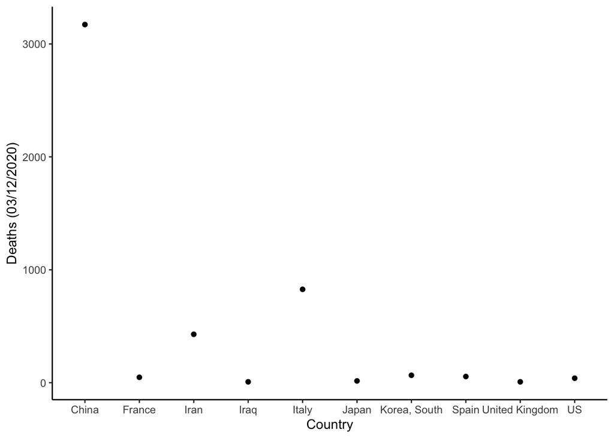

```r
library(tidyverse)

sum <- report_03_12_2020 %>%
  group_by(Country_Region)%>%
  summarize(total_deaths=sum(Deaths)) %>%
  arrange(desc(total_deaths)) %>%
  slice(1:10)

library(ggplot2)
ggplot(sum, aes(x=Country_Region, y=total_deaths)) +
  geom_point() +
  labs(x="Country", y="Deaths (03/12/2020)") +
  theme_classic()
```

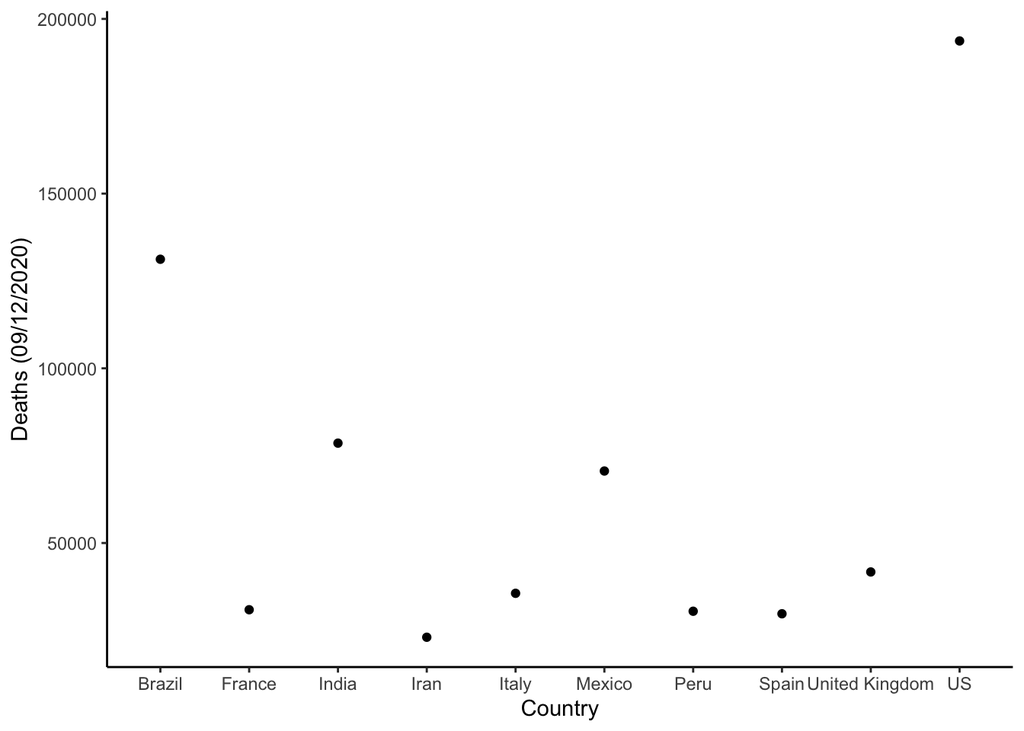

```r
library(tidyverse)

sum <- report_09_12_2020 %>%
  group_by(Country_Region)%>%
  summarize(total_deaths=sum(Deaths)) %>%
  arrange(desc(total_deaths)) %>%
  slice(1:10)

library(ggplot2)
ggplot(sum, aes(x=Country_Region, y=total_deaths)) +
  geom_point() +
  labs(x="Country", y="Deaths (09/12/2020)") +
  theme_classic()
```

### Challenge Exercise 2

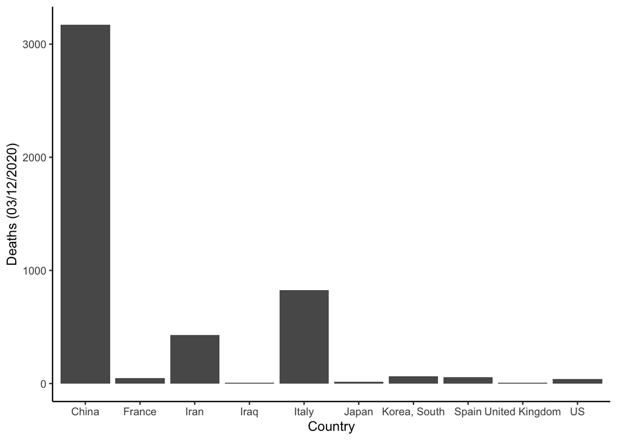

```r
library(tidyverse)

sum <- report_03_12_2020 %>%
  group_by(Country_Region)%>%
  summarize(total_deaths=sum(Deaths)) %>%
  arrange(desc(total_deaths)) %>%
  slice(1:10)

library(ggplot2)
ggplot(sum, aes(x=Country_Region, y=total_deaths)) +
  geom_bar(stat="identity") +
  labs(x="Country", y="Deaths (03/12/2020)") +
  theme_classic()
```

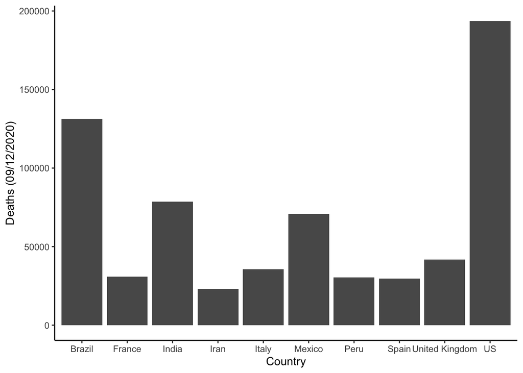

```r
library(tidyverse)

sum <- report_09_12_2020 %>%
  group_by(Country_Region)%>%
  summarize(total_deaths=sum(Deaths)) %>%
  arrange(desc(total_deaths)) %>%
  slice(1:10)

library(ggplot2)
ggplot(sum, aes(x=Country_Region, y=total_deaths)) +
  geom_bar(stat="identity") +
  labs(x="Country", y="Deaths (09/12/2020)") +
  theme_classic()
```

# Data Wrangling and Graphing COVID-19 Reporting Data (Part 2)

## Challenge Exercises

### Challenge Exercise 1

```r
library(tidyverse)

Confirmed_6_13 <- read_csv(url("https://raw.githubusercontent.com/CSSEGISandData/COVID-19/master/csse_covid_19_data/csse_covid_19_daily_reports/06-13-2020.csv")) %>%
  select(3:4, 8) %>%
  mutate(Date = lubridate::mdy("06/13/2020")) %>%
  select(Date, everything())
head(Confirmed_6_13)
```

```
## # A tibble: 6 x 4
##   Date       Province_State Country_Region Confirmed
##   <date>     <chr>          <chr>              <dbl>
## 1 2020-06-13 South Carolina US                    63
## 2 2020-06-13 Louisiana      US                   577
## 3 2020-06-13 Virginia       US                   989
## 4 2020-06-13 Idaho          US                   877
## 5 2020-06-13 Iowa           US                    11
## 6 2020-06-13 Kentucky       US                   101
```

```r
library(tidyverse)

Confirmed_9_13 <- read_csv(url("https://raw.githubusercontent.com/CSSEGISandData/COVID-19/master/csse_covid_19_data/csse_covid_19_daily_reports/09-13-2020.csv")) %>%
  select(3:4,8) %>%
  mutate(Date = lubridate::mdy("09/13/2020")) %>%
  select(Date, everything())
head(Confirmed_9_13)
```

```
## # A tibble: 6 x 4
##   Date       Province_State Country_Region      Confirmed
##   <date>     <chr>          <chr>                   <dbl>
## 1 2020-09-13 <NA>           Afghanistan             38716
## 2 2020-09-13 <NA>           Albania                 11353
## 3 2020-09-13 <NA>           Algeria                 48254
## 4 2020-09-13 <NA>           Andorra                  1344
## 5 2020-09-13 <NA>           Angola                   3388
## 6 2020-09-13 <NA>           Antigua and Barbuda        95
```

### Challenge Exercise 3

Using the time series data. Make a plot of the total number of confirmed deaths per day worldwide

```r
library(tidyverse)

time_series_deaths <- read_csv(url("https://raw.githubusercontent.com/CSSEGISandData/COVID-19/master/csse_covid_19_data/csse_covid_19_time_series/time_series_covid19_deaths_global.csv")) %>%
  rename(Province_State = "Province/State", Country_Region = "Country/Region") %>%
  gather(key="Date", value="Deaths", 5:length(.)) %>%
  mutate(Date = lubridate::mdy(Date))
head(time_series_deaths)
```

```
## # A tibble: 6 x 6
##   Province_State Country_Region        Lat   Long Date       Deaths
##   <chr>          <chr>               <dbl>  <dbl> <date>      <dbl>
## 1 <NA>           Afghanistan          33.9  67.7  2020-01-22      0
## 2 <NA>           Albania              41.2  20.2  2020-01-22      0
## 3 <NA>           Algeria              28.0   1.66 2020-01-22      0
## 4 <NA>           Andorra              42.5   1.52 2020-01-22      0
## 5 <NA>           Angola              -11.2  17.9  2020-01-22      0
## 6 <NA>           Antigua and Barbuda  17.1 -61.8  2020-01-22      0
```

```r
time_series_deaths_per_date <- time_series_deaths %>%
  group_by(Date) %>%
  summarize(Deaths = sum(Deaths)) %>%
  mutate(Deaths_per_day = Deaths - lag(Deaths))

head(time_series_deaths_per_date)
```

```
## # A tibble: 6 x 3
##   Date       Deaths Deaths_per_day
##   <date>      <dbl>          <dbl>
## 1 2020-01-22     17             NA
## 2 2020-01-23     18              1
## 3 2020-01-24     26              8
## 4 2020-01-25     42             16
## 5 2020-01-26     56             14
## 6 2020-01-27     82             26
```

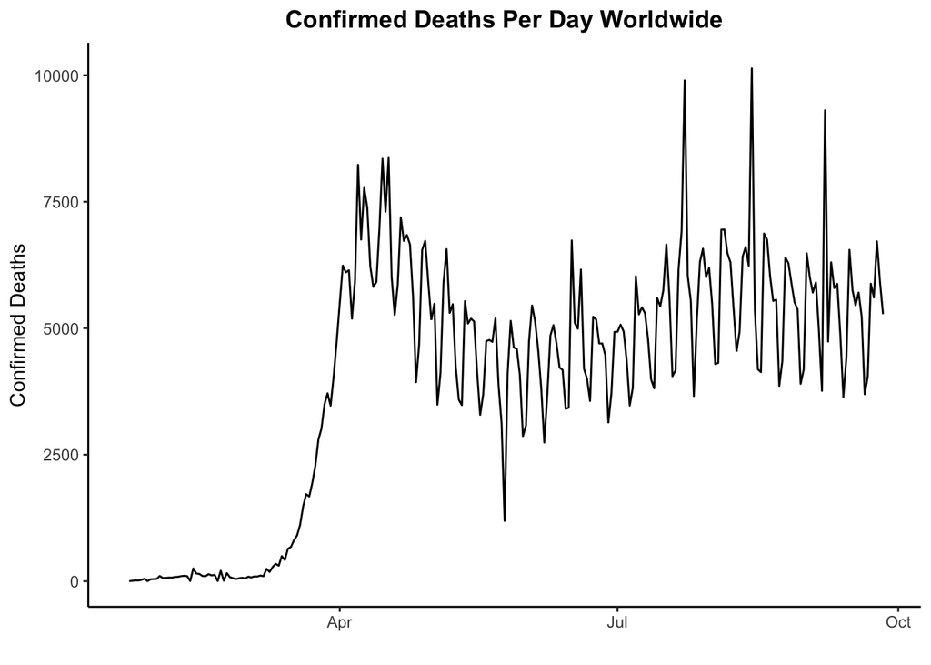

```r
library(ggplot2)

ggplot(time_series_deaths_per_date, aes(x=Date, y=Deaths_per_day)) +
  geom_line() +
  labs(x="", y="Confirmed Deaths", title="Confirmed Deaths Per Day Worldwide") +
  theme_classic() +
  theme(plot.title = element_text(hjust=0.5, face="bold"))
```

### Challenge Exercise 4

Use Mutate to make a new column with deaths/confirmed cases (Hint: this might be best done after joining the tables, but before pivoting longer).

```r
library(tidyverse)

time_series_confirmed <- read_csv(url("https://raw.githubusercontent.com/CSSEGISandData/COVID-19/master/csse_covid_19_data/csse_covid_19_time_series/time_series_covid19_confirmed_global.csv")) %>%
  rename(Province_State = "Province/State", Country_Region = "Country/Region") %>%
  mutate(report_type = "confirmed_cases") %>%
  select(report_type, everything())
head(time_series_confirmed)
```

```
## # A tibble: 6 x 254
##   report_type Province_State Country_Region   Lat   Long `1/22/20` `1/23/20`
##   <chr>       <chr>          <chr>          <dbl>  <dbl>     <dbl>     <dbl>
## 1 confirmed_… <NA>           Afghanistan     33.9  67.7          0         0
## 2 confirmed_… <NA>           Albania         41.2  20.2          0         0
## 3 confirmed_… <NA>           Algeria         28.0   1.66         0         0
## 4 confirmed_… <NA>           Andorra         42.5   1.52         0         0
## 5 confirmed_… <NA>           Angola         -11.2  17.9          0         0
## 6 confirmed_… <NA>           Antigua and B…  17.1 -61.8          0         0
## # … with 247 more variables: `1/24/20` <dbl>, `1/25/20` <dbl>, `1/26/20` <dbl>,
## #   `1/27/20` <dbl>, `1/28/20` <dbl>, `1/29/20` <dbl>, `1/30/20` <dbl>,
## #   `1/31/20` <dbl>, `2/1/20` <dbl>, `2/2/20` <dbl>, `2/3/20` <dbl>,
## #   `2/4/20` <dbl>, `2/5/20` <dbl>, `2/6/20` <dbl>, `2/7/20` <dbl>,
## #   `2/8/20` <dbl>, `2/9/20` <dbl>, `2/10/20` <dbl>, `2/11/20` <dbl>,
## #   `2/12/20` <dbl>, `2/13/20` <dbl>, `2/14/20` <dbl>, `2/15/20` <dbl>,
## #   `2/16/20` <dbl>, `2/17/20` <dbl>, `2/18/20` <dbl>, `2/19/20` <dbl>,
## #   `2/20/20` <dbl>, `2/21/20` <dbl>, `2/22/20` <dbl>, `2/23/20` <dbl>,
## #   `2/24/20` <dbl>, `2/25/20` <dbl>, `2/26/20` <dbl>, `2/27/20` <dbl>,
## #   `2/28/20` <dbl>, `2/29/20` <dbl>, `3/1/20` <dbl>, `3/2/20` <dbl>,
## #   `3/3/20` <dbl>, `3/4/20` <dbl>, `3/5/20` <dbl>, `3/6/20` <dbl>,
## #   `3/7/20` <dbl>, `3/8/20` <dbl>, `3/9/20` <dbl>, `3/10/20` <dbl>,
## #   `3/11/20` <dbl>, `3/12/20` <dbl>, `3/13/20` <dbl>, `3/14/20` <dbl>,
## #   `3/15/20` <dbl>, `3/16/20` <dbl>, `3/17/20` <dbl>, `3/18/20` <dbl>,
## #   `3/19/20` <dbl>, `3/20/20` <dbl>, `3/21/20` <dbl>, `3/22/20` <dbl>,
## #   `3/23/20` <dbl>, `3/24/20` <dbl>, `3/25/20` <dbl>, `3/26/20` <dbl>,
## #   `3/27/20` <dbl>, `3/28/20` <dbl>, `3/29/20` <dbl>, `3/30/20` <dbl>,
## #   `3/31/20` <dbl>, `4/1/20` <dbl>, `4/2/20` <dbl>, `4/3/20` <dbl>,
## #   `4/4/20` <dbl>, `4/5/20` <dbl>, `4/6/20` <dbl>, `4/7/20` <dbl>,
## #   `4/8/20` <dbl>, `4/9/20` <dbl>, `4/10/20` <dbl>, `4/11/20` <dbl>,
## #   `4/12/20` <dbl>, `4/13/20` <dbl>, `4/14/20` <dbl>, `4/15/20` <dbl>,
## #   `4/16/20` <dbl>, `4/17/20` <dbl>, `4/18/20` <dbl>, `4/19/20` <dbl>,
## #   `4/20/20` <dbl>, `4/21/20` <dbl>, `4/22/20` <dbl>, `4/23/20` <dbl>,
## #   `4/24/20` <dbl>, `4/25/20` <dbl>, `4/26/20` <dbl>, `4/27/20` <dbl>,
## #   `4/28/20` <dbl>, `4/29/20` <dbl>, `4/30/20` <dbl>, `5/1/20` <dbl>,
## #   `5/2/20` <dbl>, …
```

```r
library(tidyverse)

time_series_deaths <- read_csv(url("https://raw.githubusercontent.com/CSSEGISandData/COVID-19/master/csse_covid_19_data/csse_covid_19_time_series/time_series_covid19_deaths_global.csv")) %>%
  rename(Province_State = "Province/State", Country_Region = "Country/Region") %>%
  mutate(report_type = "confirmed_deaths") %>%
  select(report_type, everything())
head(time_series_deaths)
```

```
## # A tibble: 6 x 254
##   report_type Province_State Country_Region   Lat   Long `1/22/20` `1/23/20`
##   <chr>       <chr>          <chr>          <dbl>  <dbl>     <dbl>     <dbl>
## 1 confirmed_… <NA>           Afghanistan     33.9  67.7          0         0
## 2 confirmed_… <NA>           Albania         41.2  20.2          0         0
## 3 confirmed_… <NA>           Algeria         28.0   1.66         0         0
## 4 confirmed_… <NA>           Andorra         42.5   1.52         0         0
## 5 confirmed_… <NA>           Angola         -11.2  17.9          0         0
## 6 confirmed_… <NA>           Antigua and B…  17.1 -61.8          0         0
## # … with 247 more variables: `1/24/20` <dbl>, `1/25/20` <dbl>, `1/26/20` <dbl>,
## #   `1/27/20` <dbl>, `1/28/20` <dbl>, `1/29/20` <dbl>, `1/30/20` <dbl>,
## #   `1/31/20` <dbl>, `2/1/20` <dbl>, `2/2/20` <dbl>, `2/3/20` <dbl>,
## #   `2/4/20` <dbl>, `2/5/20` <dbl>, `2/6/20` <dbl>, `2/7/20` <dbl>,
## #   `2/8/20` <dbl>, `2/9/20` <dbl>, `2/10/20` <dbl>, `2/11/20` <dbl>,
## #   `2/12/20` <dbl>, `2/13/20` <dbl>, `2/14/20` <dbl>, `2/15/20` <dbl>,
## #   `2/16/20` <dbl>, `2/17/20` <dbl>, `2/18/20` <dbl>, `2/19/20` <dbl>,
## #   `2/20/20` <dbl>, `2/21/20` <dbl>, `2/22/20` <dbl>, `2/23/20` <dbl>,
## #   `2/24/20` <dbl>, `2/25/20` <dbl>, `2/26/20` <dbl>, `2/27/20` <dbl>,
## #   `2/28/20` <dbl>, `2/29/20` <dbl>, `3/1/20` <dbl>, `3/2/20` <dbl>,
## #   `3/3/20` <dbl>, `3/4/20` <dbl>, `3/5/20` <dbl>, `3/6/20` <dbl>,
## #   `3/7/20` <dbl>, `3/8/20` <dbl>, `3/9/20` <dbl>, `3/10/20` <dbl>,
## #   `3/11/20` <dbl>, `3/12/20` <dbl>, `3/13/20` <dbl>, `3/14/20` <dbl>,
## #   `3/15/20` <dbl>, `3/16/20` <dbl>, `3/17/20` <dbl>, `3/18/20` <dbl>,
## #   `3/19/20` <dbl>, `3/20/20` <dbl>, `3/21/20` <dbl>, `3/22/20` <dbl>,
## #   `3/23/20` <dbl>, `3/24/20` <dbl>, `3/25/20` <dbl>, `3/26/20` <dbl>,
## #   `3/27/20` <dbl>, `3/28/20` <dbl>, `3/29/20` <dbl>, `3/30/20` <dbl>,
## #   `3/31/20` <dbl>, `4/1/20` <dbl>, `4/2/20` <dbl>, `4/3/20` <dbl>,
## #   `4/4/20` <dbl>, `4/5/20` <dbl>, `4/6/20` <dbl>, `4/7/20` <dbl>,
## #   `4/8/20` <dbl>, `4/9/20` <dbl>, `4/10/20` <dbl>, `4/11/20` <dbl>,
## #   `4/12/20` <dbl>, `4/13/20` <dbl>, `4/14/20` <dbl>, `4/15/20` <dbl>,
## #   `4/16/20` <dbl>, `4/17/20` <dbl>, `4/18/20` <dbl>, `4/19/20` <dbl>,
## #   `4/20/20` <dbl>, `4/21/20` <dbl>, `4/22/20` <dbl>, `4/23/20` <dbl>,
## #   `4/24/20` <dbl>, `4/25/20` <dbl>, `4/26/20` <dbl>, `4/27/20` <dbl>,
## #   `4/28/20` <dbl>, `4/29/20` <dbl>, `4/30/20` <dbl>, `5/1/20` <dbl>,
## #   `5/2/20` <dbl>, …
```

```r
library(tidyverse)

time_series_joined <- bind_rows(time_series_confirmed, time_series_deaths) %>%
  gather(key="date", value="count", 6:length(.)) %>%
  mutate(date=lubridate::mdy(date)) %>%
  spread(key="report_type", value="count") %>%
  mutate(confirmed_cases=replace_na(confirmed_cases, 0),
         confirmed_deaths=replace_na(confirmed_deaths, 0))

head(time_series_joined)
```

```
## # A tibble: 6 x 7
##   Province_State Country_Region   Lat   Long date       confirmed_cases
##   <chr>          <chr>          <dbl>  <dbl> <date>               <dbl>
## 1 <NA>           Afghanistan     33.9  67.7  2020-01-22               0
## 2 <NA>           Albania         41.2  20.2  2020-01-22               0
## 3 <NA>           Algeria         28.0   1.66 2020-01-22               0
## 4 <NA>           Andorra         42.5   1.52 2020-01-22               0
## 5 <NA>           Angola         -11.2  17.9  2020-01-22               0
## 6 <NA>           Antigua and B…  17.1 -61.8  2020-01-22               0
## # … with 1 more variable: confirmed_deaths <dbl>
```

```r
tail(time_series_joined)
```

```
## # A tibble: 6 x 7
##   Province_State Country_Region   Lat  Long date       confirmed_cases
##   <chr>          <chr>          <dbl> <dbl> <date>               <dbl>
## 1 <NA>           Syria           34.8  39.0 2020-09-26               0
## 2 <NA>           United Arab E…  23.4  53.8 2020-09-26               0
## 3 Montserrat     United Kingdom  16.7 -62.2 2020-09-26               0
## 4 Turks and Cai… United Kingdom  21.7 -71.8 2020-09-26               0
## 5 <NA>           Vietnam         14.1 108.  2020-09-26               0
## 6 <NA>           Yemen           15.6  48.5 2020-09-26               0
## # … with 1 more variable: confirmed_deaths <dbl>
```

```r
library(tidyverse)

time_series_sum <- time_series_joined %>%
  group_by(date) %>%
  summarize(cases = sum(confirmed_cases),
            deaths = sum(confirmed_deaths)) %>%
  mutate(deaths_cases = deaths/cases)

head(time_series_sum)
```

```
## # A tibble: 6 x 4
##   date       cases deaths deaths_cases
##   <date>     <dbl>  <dbl>        <dbl>
## 1 2020-01-22   555     17       0.0306
## 2 2020-01-23   654     18       0.0275
## 3 2020-01-24   941     26       0.0276
## 4 2020-01-25  1434     42       0.0293
## 5 2020-01-26  2118     56       0.0264
## 6 2020-01-27  2927     82       0.0280
```

### Challenge Exercise 5

Plot US deaths/confirmed cases per day.

```r
library(tidyverse)

time_series_sum <- time_series_joined %>%
  filter(Country_Region=="US") %>%                      #| Filter only US Data
  group_by(date) %>%
  summarize(cases = sum(confirmed_cases),
            deaths = sum(confirmed_deaths)) %>%
  mutate(deaths_cases = deaths/cases)
```

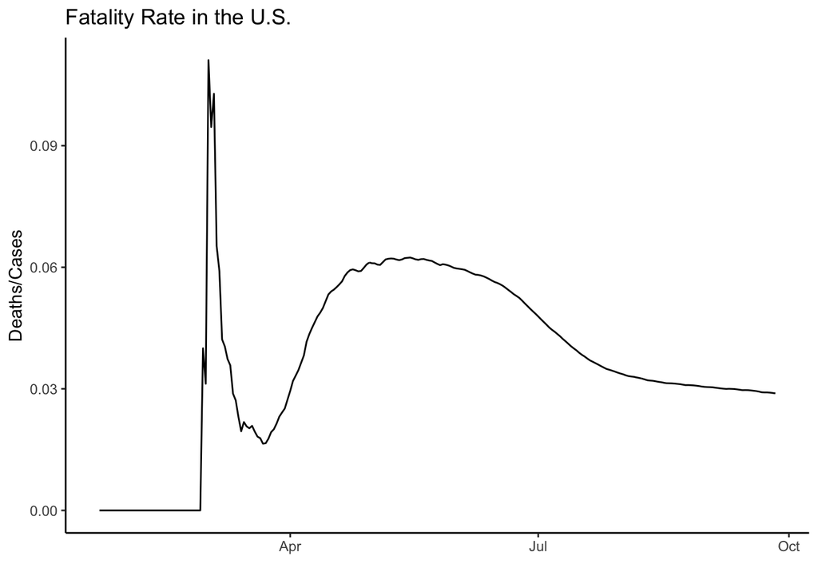

```r
library(ggplot2)

ggplot(time_series_sum, aes(x=date, y=deaths_cases)) +
  geom_line() +
  labs(x="", y="Deaths/Cases", title="Fatality Rate in the U.S.") +
  theme_classic()
```

### Challenge Exercise 6

Make a single graph with from the times series data with the 10 countries with the hightest death total.

```r
library(tidyverse)

time_series_deaths <- read_csv(url("https://raw.githubusercontent.com/CSSEGISandData/COVID-19/master/csse_covid_19_data/csse_covid_19_time_series/time_series_covid19_deaths_global.csv")) %>%
  rename(Province_State = "Province/State", Country_Region = "Country/Region") %>%
  gather(key="date", value="count", 5:length(.)) %>%
  mutate(date = lubridate::mdy(date))
tail(time_series_deaths)
```

```
## # A tibble: 6 x 6
##   Province_State Country_Region       Lat  Long date       count
##   <chr>          <chr>              <dbl> <dbl> <date>     <dbl>
## 1 <NA>           Vietnam             14.1 108.  2020-09-26    35
## 2 <NA>           West Bank and Gaza  32.0  35.2 2020-09-26   285
## 3 <NA>           Western Sahara      24.2 -12.9 2020-09-26     1
## 4 <NA>           Yemen               15.6  48.5 2020-09-26   587
## 5 <NA>           Zambia             -13.1  27.8 2020-09-26   332
## 6 <NA>           Zimbabwe           -19.0  29.2 2020-09-26   227
```

```r
library(tidyverse)

time_series_top_deaths <- time_series_deaths %>%
  filter(date=="2020-09-26") %>%
  group_by(Country_Region) %>%
  summarize(total_deaths = sum(count)) %>%
  arrange(desc(total_deaths)) %>%
  slice(1:10)

head(time_series_top_deaths)
```

```
## # A tibble: 6 x 2
##   Country_Region total_deaths
##   <chr>                 <dbl>
## 1 US                   204490
## 2 Brazil               141406
## 3 India                 94503
## 4 Mexico                76243
## 5 United Kingdom        42060
## 6 Italy                 35818
```

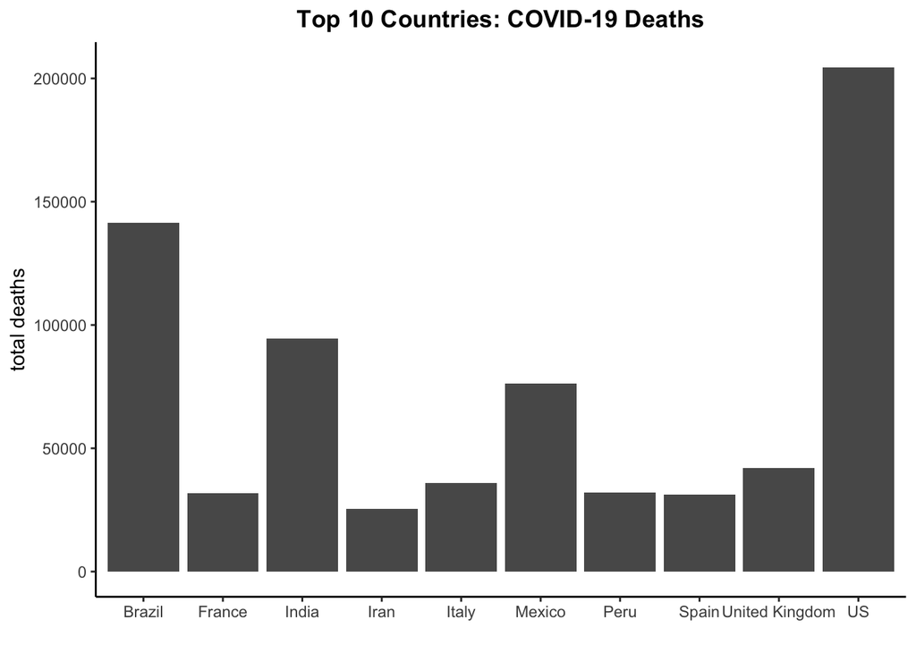

```r
library(ggplot2)

ggplot(time_series_top_deaths, aes(x=Country_Region, y=total_deaths)) +
  geom_bar(stat="identity") +
  labs(x="", y="total deaths", title="Top 10 Countries: COVID-19 Deaths") +
  theme_classic() +
  theme(plot.title = element_text(hjust = 0.5, face="bold"))
```

### Challenge Exercise 7

Using Facet_Wraps make a graph from the times series data with the 10 countries with the hightest death total. Format the table to look nice in the report by changing the number of rows in your graph and/or adjusting the height in the R code chunk header.

```r
library(tidyverse)

time_series_deaths <- read_csv(url("https://raw.githubusercontent.com/CSSEGISandData/COVID-19/master/csse_covid_19_data/csse_covid_19_time_series/time_series_covid19_deaths_global.csv")) %>%
  rename(Province_State = "Province/State", Country_Region = "Country/Region") %>%
  gather(key="date", value="count", 5:length(.)) %>%
  mutate(date = lubridate::mdy(date)) %>%
  filter(Country_Region %in% c("Brazil", "France", "India", "Iran", "Italy", "Mexico", "Peru", "Spain", "United Kingdom", "US")) %>%
  group_by(date, Country_Region) %>%
  summarize(total_deaths = sum(count))
head(time_series_deaths)
```

```
## # A tibble: 6 x 3
## # Groups:   date [1]
##   date       Country_Region total_deaths
##   <date>     <chr>                 <dbl>
## 1 2020-01-22 Brazil                    0
## 2 2020-01-22 France                    0
## 3 2020-01-22 India                     0
## 4 2020-01-22 Iran                      0
## 5 2020-01-22 Italy                     0
## 6 2020-01-22 Mexico                    0
```

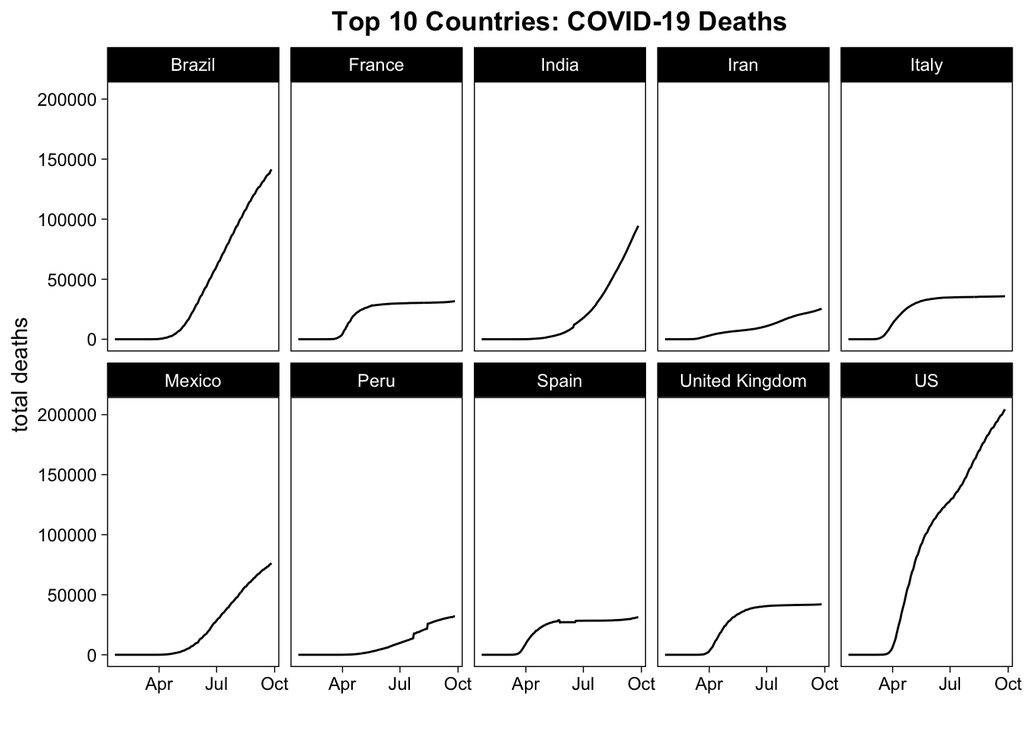

```r
library(ggplot2)

ggplot(time_series_deaths, aes(x=date, y=total_deaths)) +
  geom_line() +
  labs(x="", y="total deaths", title="Top 10 Countries: COVID-19 Deaths") +
  facet_wrap(~Country_Region, ncol=5) +
  theme_linedraw() +
  theme(plot.title = element_text(hjust=0.5, face="bold"),
        panel.grid.major = element_blank(),
        panel.grid.minor = element_blank())
```

### Challenge Exercise 8

Using Facet_Wraps make a graph from the times series data for confirmed cases for all US states and territories. (Hint: Instead of the global time series use the US time series data in the same folder time_series_covid19_deaths_US.csv and time_series_covid19_confirmed_US) Format the table to look nice in the report by changing the number of rows in your graph and/or adjusting the height in the R code chunk header.

```r
library(tidyverse)

time_series_confirmed <- read_csv(url("https://raw.githubusercontent.com/CSSEGISandData/COVID-19/master/csse_covid_19_data/csse_covid_19_time_series/time_series_covid19_confirmed_US.csv")) %>%
  select(7:length(.)) %>%
  gather(key="date", value="cases", 6:length(.)) %>%
  mutate(date = lubridate::mdy(date)) %>%
  group_by(date, Province_State) %>%
  summarize(total_cases = sum(cases))
head(time_series_confirmed)
```

```
## # A tibble: 6 x 3
## # Groups:   date [1]
##   date       Province_State total_cases
##   <date>     <chr>                <dbl>
## 1 2020-01-22 Alabama                  0
## 2 2020-01-22 Alaska                   0
## 3 2020-01-22 American Samoa           0
## 4 2020-01-22 Arizona                  0
## 5 2020-01-22 Arkansas                 0
## 6 2020-01-22 California               0
```

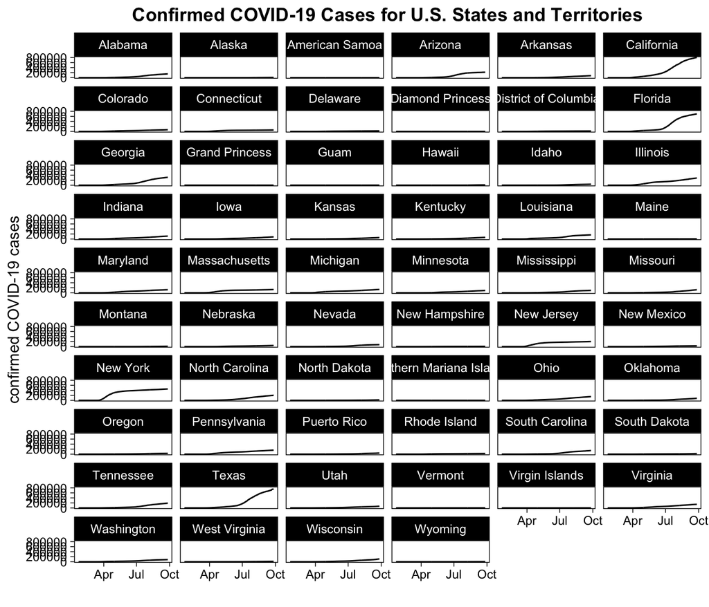

```r
options(scipen=5)

library(ggplot2)

ggplot(time_series_confirmed, aes(x=date, y=total_cases)) +
  geom_line() +
  labs(x="", y="confirmed COVID-19 cases", title="Confirmed COVID-19 Cases for U.S. States and Territories") +
  facet_wrap(~Province_State, ncol=6) +
  theme_linedraw() +
  theme(plot.title=element_text(hjust=0.5, face="bold"),
        panel.grid.major=element_blank(),
        panel.grid.minor=element_blank())
```

### Challenge Exercise 9

Apply a theme other than the one used in the Data Carpentries tutorial to the graph in Ex8.

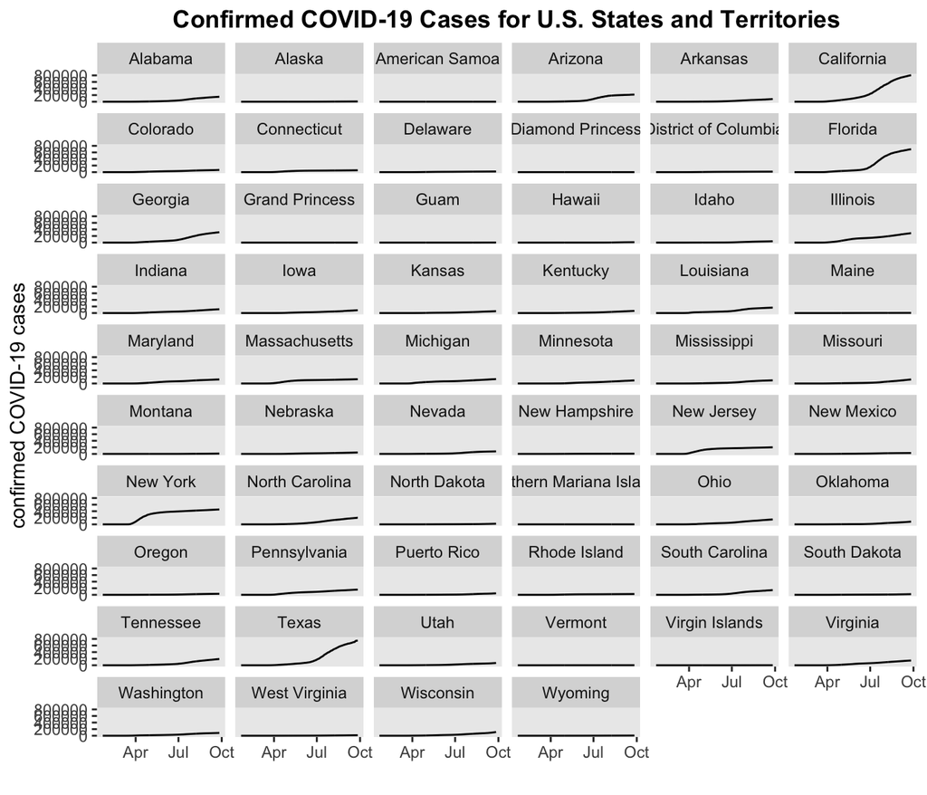

```r
options(scipen=5)

library(ggplot2)

ggplot(time_series_confirmed, aes(x=date, y=total_cases)) +
  geom_line() +
  labs(x="", y="confirmed COVID-19 cases", title="Confirmed COVID-19 Cases for U.S. States and Territories") +
  facet_wrap(~Province_State, ncol=6) +
  theme_grey() +
  theme(plot.title=element_text(hjust=0.5, face="bold"),
        panel.grid.major=element_blank(),
        panel.grid.minor=element_blank())
```